# Excess count detection for epidemiological time series

Benedikt Zacher

2025-10-10

**Ex**cess **c**ount **de**tection (*excode*) in epidemiological time series is an important part of public health surveillance systems. A variety of algorithms has been developed to identify events such as disease outbreaks or excess mortality. To this end, time series are analysed to detect unusually large (case) counts, that exceed what is normally expected in a certain time period and geographical region. The normal expectancy of cases in a current time period is usually calculated based on historic data. Depending on the time series of interest, the following features need to be taken into account by a model:

- **Seasonal patterns:** Many epidemiological times series that are of public health interest show periodic changes in cases depending on seasons or other calendar periods.
- **Long-term time trends:** The time series may show a long-term increase or decrease in case counts.
- **Historic events:** Events such as disease outbreaks may have caused an excess of case counts in historic data that is used for model estimation. This needs to be considered to avoid overestimation of the normal expectancy for the current time period.

The *excode* package provides a flexible framework that implements well established approaches to control for seasonality, long-term trends and historic events, but also allows the use of customized models. The user can choose between the Poisson and the Negative Binomial distribution, which are the most commonly used probability distributions for modeling count data. By combining hidden Markov models and generalized linear models, *excode* explicitly models normally expected case counts *and* expected excess case counts, i.e. each time point in a time series is labeled either as a normal state or as an excess state. A short overview of the statistical model used can be found at the end of this document.

## Overwiew of available models in *excode*

There are four different model classes implemented in *excode*:

- **Mean:** This model does not account for seasonal or cyclical patterns. The expectancy of normal and excess case counts is modeled as the mean of the historic data.
- **FarringtonNoufaily:** This is a popular algorithm, which models seasonality by segmenting a year into a predefined number of shorter time periods, where each has a different expectancy of observed cases. It also allows integration of a long-term time trend.
- **Harmonic:** The ‘Harmonic’ model uses sine and cosine function to account for seasonal or cyclical patterns in the data. It also allows integration of long-term time trends.
- **Custom:** The ‘Custom’ model allows the user define their own model by providing a data frame containing covariate data.

All of the above mentioned models use one ‘normal’ and one or more ‘excess’ states. In order to detect potential disease outbreaks, two states are sufficient in most scenarios. However in some cases it might be necessary to allow multiple states, such as ‘normal’, ‘low excess’, ‘medium excess’, ‘high excess’, to account for a wide range of excess counts and detect all periods showing an excess in a time series.

## Using *excode* for excess count detection

```r
library(excode)
```

The input data is a `data.frame` with at least two variables containing dates and the observed number of cases:

- **date**: The date of the event (e.g. reporting date, date of disease onset, date of death)
- **observed**: The observed number of cases.

Optional variables can be:

- **offset** (optional): This could be e.g. the susceptible population.
- **state** (optional): This can used to indicate time points in the data where there is no excess and can be either `0=normal` or `NA=unknown`.

The example data `shadar_df` in this section contains the number of weekly cases of *Salmonella hadar* from 2001 until 2006 in Germany (taken from the [surveillance package](https://cran.r-project.org/web/packages/surveillance/index.html)). This dataset does not contain an **offset** and **state** variable as we do not adjust for population size and the true disease outbreak labels are not included.

```r
## Load data and show first 6 rows
data("shadar_df")
kable(as_tibble(shadar_df[1:6, ])) %>%
  kable_styling(font_size = 11)
```

| date | observed |
| --- | --- |
| 2001-01-08 | 1 |
| 2001-01-15 | 6 |
| 2001-01-22 | 3 |
| 2001-01-29 | 3 |
| 2001-02-05 | 15 |
| 2001-02-12 | 5 |

In this example, the ‘Poisson’ distribution and the ‘Harmonic’ model is chosen to account for the seasonal patterns and long-term time trend. Excess count detection is carried using the `run_excode()` function. If time points with excess is expected to be rare (e.g. for disease outbreak detection) it is recommended to set `set_baseline_state = TRUE`. This assigns low case counts to the `normal` state and improves model fitting.

```r
result_shadar_har <- run_excode(
    surv_ts = shadar_df,
    timepoints = 209:295,
    distribution = "Poisson",
    states = 2,
    periodic_model = "Harmonic",
    time_trend = "Linear",
    return_full_model = FALSE,
    set_baseline_state = TRUE
)
```

Results can be extracted using the `summary()` function:

```r
summary_shadar_har <- summary(result_shadar_har)
kable(as_tibble(summary_shadar_har[82:87, ])) %>%
  kable_styling(font_size = 11)
```

| posterior0 | posterior1 | pval | zscore | date | timepoint | observed | mu0 | mu1 | BIC | AIC |
| --- | --- | --- | --- | --- | --- | --- | --- | --- | --- | --- |
| 0.015 | 0.985 | 0.002 | 2.99 | 2006-07-24 | 290 | 10 | 3.29 | 10.9 | 1117 | 1034 |
| 0.000 | 1.000 | 0.000 | 4.84 | 2006-07-31 | 291 | 16 | 3.61 | 11.9 | 1127 | 1043 |
| 0.000 | 1.000 | 0.000 | 6.17 | 2006-08-07 | 292 | 21 | 3.86 | 12.9 | 1138 | 1054 |
| 0.290 | 0.710 | 0.036 | 1.93 | 2006-08-14 | 293 | 8 | 3.72 | 12.4 | 1141 | 1058 |
| 0.045 | 0.955 | 0.001 | 3.29 | 2006-08-21 | 294 | 12 | 3.92 | 12.9 | 1153 | 1070 |
| 0.867 | 0.133 | 0.188 | 1.03 | 2006-08-28 | 295 | 6 | 3.83 | 12.4 | 1149 | 1066 |

The result is a `data.frame` with the following variables:

- **posterior0:** Probability for the `normal` state the current time point.
- **posterior1:** Probability that there is an `excess` of case counts at the current time point.
- **pval:** P-value for the null hypothesis that there is no excess at the current timepoint.
- **zscore:** Measures how many standard deviations the observed number of cases is from the mu0. A value of `2.33` corresponds to a p-value of `0.01`.
- **date:** The event date (e.g. reporting date or date of disease onset).
- **timepoint:** Timepoint (as integer) in the time series.
- **observed:** Number of cases at the current time point.
- **mu0:** Number of expected cases under normal conditions.
- **mu1:** Number of expected cases under excess conditions.
- **id:** Name of the time series.
- **BIC:** Bayesian information criterion.
- **AIC:** Aikake information criterion.

The result summary can visualised using the `plot_excode_summary()` function. Figure 1 shows that there is a cyclical pattern of case counts, with more cases during the summer and fewer cases cases during the winter There is also a decrease of reported cases over the years, except for the year 2006, [where an outbreak lead to a surge in case numbers compared to previous years](https://www.rki.de/DE/Content/Infekt/EpidBull/Archiv/2006/Ausgabenlinks/31_06.pdf?__blob=publicationFile).

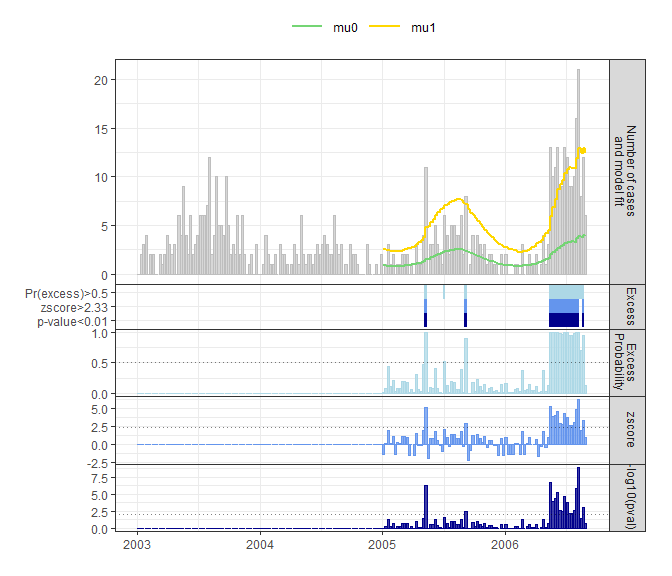

**Figure 1:** Weekly *Salmonella Hadar* cases with alarm thresholds (upper bounds).

```r
#plot_excode_summary(summary_shadar_har, type="bar")
plot_excode_summary(bind_rows(shadar_df %>%
                                dplyr::filter(!date %in% summary_shadar_har$date &
                                                lubridate::year(shadar_df$date)>=2003),
                              summary_shadar_har) %>%
                                mutate(posterior0=ifelse(is.na(posterior0), 1, posterior0),
                                       zscore=ifelse(is.na(zscore), 0, zscore),
                                        pval=ifelse(is.na(pval), 1, pval))
                    , type="bar")
```

Models ‘Mean’ and ‘FarringtonNoufaily’ can be applied likewise.

## The ‘Custom’ model

```r
data(sarscov2_df)
num_wday <- wday(sarscov2_df$date, week_start = 1)
weekday <- data.frame(day = factor(ifelse(num_wday <= 5, "workday", "weekend"),
  levels = c("workday", "weekend")
))
```

```r
result_sarscov2_custom <- run_excode(
    surv_ts = sarscov2_df,
    covariate_df = weekday,
    states = 2,
    distribution = "Poisson",
    periodic_model = "Custom",
    timepoints = 93:154,
    time_units_back = 8,
    period_length = 7,
    return_full_model = FALSE,
    set_baseline_state = TRUE
)

summary_sarscov2_custom <- summary(result_sarscov2_custom)
```

The results can be plotted as follows:

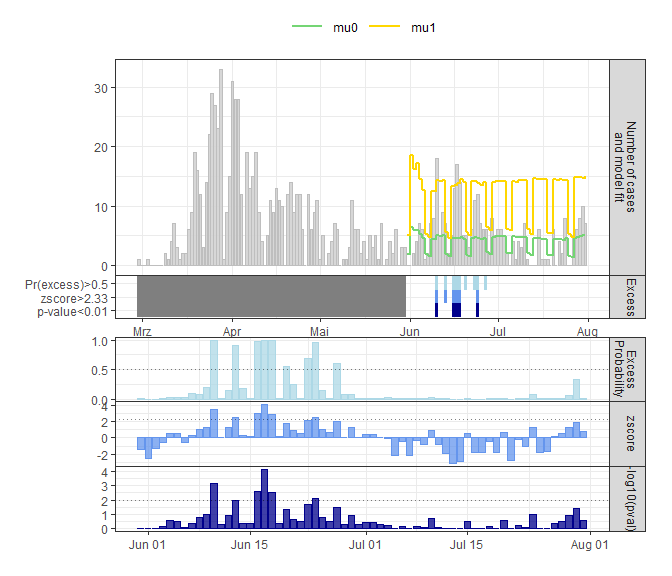

**Figure 2:** Daily reported SARS-CoV-2 infections in Berlin-Neukölln with alarm thresholds (upper bounds).

```r
plot_excode_summary(bind_rows(sarscov2_df %>% dplyr::filter(!date %in%summary_sarscov2_custom$date), summary_sarscov2_custom), type="bar")
```

## Initialisation with known `normal` states

```r
data("mort_df_germany")
```

```r
kable(as_tibble(mort_df_germany[15:20, ])) %>%
  kable_styling(font_size = 11)
```

| date | observed | state |
| --- | --- | --- |
| 2016-04-10 | 18242 | NA |
| 2016-04-17 | 17710 | NA |
| 2016-04-24 | 16774 | 0 |
| 2016-05-01 | 17050 | 0 |
| 2016-05-08 | 16899 | 0 |
| 2016-05-15 | 17629 | 0 |

The ‘MultiState’ model can now be fitted using `run_excode()` as usual:

```r
result_mort <- run_excode(
    surv_ts = mort_df_germany,
    covariate_df = weekday,
    states = 3,
    distribution = "NegBinom",
    periodic_model = "Harmonic",
    time_trend = "Spline2",
    timepoints = nrow(mort_df_germany),
    return_full_model = TRUE
)
```

```
## No `offset` column; assuming offset = 1 for all rows.
```

```
## Additional columns in `surv_ts` will be passed through/ignored as appropriate: id
```

```r
summary_mort <- summary(result_mort)
```

The results and weekly excess probablities can be plottad as follows:

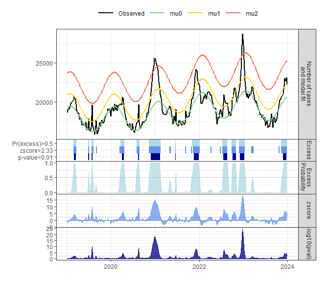

```r
plot_excode_summary(summary_mort)
```

## A short overview of the statistical model

The *excode* package combines Generalized Linear Models (GLMs) with Hidden Markov Models (HMMs). The GLM part of the model allows to use regression models to model seasonal patterns and general trends in the time series. Besides seasonal patterns and general time trends, an algorithm for excess count detection needs to account for excess counts in the historic data used for model estimation. The HMM part of the statistical model used in *excode* allows to explicitly consider past disease outbreaks in the model. The HMM separates the time series in two (or more) states: the normal state and one (or multiple) excess state. In the normal state, observed case counts lie within the range of what is normally expected in a certain time period. In the excess state, case counts are higher than what is normally expected, i.e. there is a potential outbreak or excess mortality. This is in contrast most of other algorithms used for excess count detection, which either do not account for previous excess case counts or use some heuristic for down weighting past instances of excess counts.

- Initial state probabilities $\Pr(s_{1}=N\bigr)$ and $\Pr(s_{1}=E\bigr)$ give the probability that the first time point of the time series is in the respective state.
- Transition probabilities give the probability that time point $t$ is in a specific state, given the state of the previous time point. For instance, $\Pr\left(s_{t}=N\left|s_{t-1}=N\right.\right)$, $t\in\left[1;T\right]$ gives the probability that the time series is in the normal state at time point $t$, given that position $t-1$ is also in the normal state. $\Pr\left(s_{t}=E\left|s_{t-1}=N\right.\right)$ gives the probability to transition to the excess state at time point $t$, given that $t-1$ is in the normal state.

The expected case counts at position $t$, $\mu_t$ are modeled using a GLM using sine and cosine functions to control for seasonal patterns (which is one of the models available in *excode*):

$$\log\mu_{t}=\beta_{0}+\beta_{1}t+ \beta_3 \cos(\frac{2\pi}{52}t) +
\beta_4\sin(\frac{2\pi}{52}t) +
\beta_{5}I\left(s_{t}=E\right)$$

Here, $\beta_{0}$ is the intercept, $\beta_{1}t$ a linear time trend, $\beta_3$ and $\beta_4$ model the seasonal patterns using $\sin$ and $\cos$ functions with weekly data (52 time points per year). The increase in cases is incorporated by $\beta_{5}$.

Based on this model, *excode* calculates a probability that there is an excess of case counts at the current time point - the posterior probability. Moreover, given the normally expected case counts in the model, a p-value for the null hypothesis, that there is no excess at the current timepoint is calculated. The z-score is calculated based on a quasi-Poisson regression as described in [EuroMOMO](https://www.destatis.de/DE/Themen/Gesellschaft-Umwelt/Bevoelkerung/Sterbefaelle-Lebenserwartung/sterbefallzahlen.html).